# Inferring Cell Type estimates

Urwah Nawaz

2023-09-24

# Introduction

This R markdown document contains the complete code to perform the deconvolution analysis of the bulk RNA-seq datasets for Brain Integrative Transcriptome Hub (BITHub). All datasets were pre-possessed using the code in `metadata-preprocess.Rmd`. In order to re-run the scripts - make sure to change the directories to the location of where the input files for pre-processing are stored. All directories are defined in each dataset section.

```r
library(magrittr)
library(tibble)
library(reshape2)
library(SummarizedExperiment)
library(dplyr)
library(gridExtra)
library(preprocessCore)
library(Metrics)
library(DTWBI)
library(purrr)
source(here::here("code/fun-cibersort.R"))
source(here::here("code/functions.R"))
load(here::here("data/cell-type-signatures/sigsBrain.rda"))
```

```r
paths <- yaml::read_yaml(here::here("config/paths-example.yaml"))

read_expr2 <- function(dir, expr, rownames, drop_cols = NULL) {

  df <- readr::read_csv(
    file.path(dir, expr),
    show_col_types = FALSE,
    name_repair = "minimal"
  )
  nms <- names(df)
  if (any(nms == "")) {
    nms[nms == ""] <- "X"
    names(df) <- make.unique(nms)
  }

  if (!is.null(drop_cols)) {
    df <- df[, !names(df) %in% drop_cols, drop = FALSE]
  }
  rn_col <- if (is.numeric(rownames)) names(df)[[ rownames]] else rownames

  df <- tibble::column_to_rownames(df, rn_col)

  as.data.frame(df, check.names = FALSE)
}

e <- purrr::imap(
  paths$bulk$formatted,
  \(x, key) read_expr2(
    dir = x$dir,
    expr = x$expr,
    rownames = x$rownames,
    drop_cols = if (!is.null(x$drop_cols)) x$drop_cols else NULL
  )
)
```

## Run deconvolution analysis

CIBERSORT is used for the analysis, and MultiBrain signatures generated in Sutton et al (2022) are used for signatures.

NOTE: For the purpose of generating this notebook, the CIBERSORT analysis has been commented out.The CIBERSORT analysis on these datasets took ~2 days to run on a 16 core machine.

## Goodness-of-fit and deconvolution results

The performance of the deconvolution analysis was evaluated using a goodness-of-fit (r) measurement, which is based on the Pearson’s correlation coefficient between the expression data and measured expression data.

The goodness-of-fit measurement was performed for each of the datasets.

```r
load(here::here("output/deconvolution/Deconvolution_results_multibrain.Rda"))
```

```r
datasets <- intersect(names(e), names(decon_results))

gof_results <- lapply(datasets, function(ds) {
  write.gof(
    e[[ds]],
    decon_results[[ds]],
    sigsBrain$MB
  )
})

names(gof_results) <- datasets
```

```r
gof_results$brainseq %<>%
  rownames_to_column("SampleID") %>%
  left_join(read.csv(here::here("output/metadata/BrainSeq-metadata.csv")) %>%
              dplyr::select(SampleID, Regions, Period), by = "SampleID") %>%
  mutate(Dataset = c("BrainSeq"))


gof_results$brainspan %<>%
  rownames_to_column("SampleID") %>%
  mutate(SampleID = gsub("^X","", SampleID)) %>%
  left_join(read.csv(here::here("output/metadata/BrainSpan-metadata.csv")) %>%
              dplyr::select(SampleID, Regions, Period), by = "SampleID") %>%
  mutate(Dataset = c("BrainSpan"))


gof_results$gtex %<>%
  rownames_to_column("SampleID") %>%
  mutate(SampleID = gsub("\\.","-", SampleID)) %>%
  left_join(read.csv(here::here("output/metadata/GTEx-metadata.csv")) %>%
              dplyr::select(SampleID, Regions, Period), by = "SampleID") %>%
  mutate(Dataset = c("GTEx"))


gof_results$hdbr %<>%
  rownames_to_column("SampleID") %>%
  mutate(SampleID = gsub("^X","", SampleID)) %>%
  left_join(read.csv(here::here("output/metadata/HDBR-metadata.csv")) %>%
              dplyr::select(SampleID, Regions, Period), by = "SampleID") %>%
  mutate(Dataset = c("HDBR"))

gof_results$psychencode %<>%
  rownames_to_column("SampleID") %>%
  mutate(SampleID = gsub("^X","", SampleID)) %>%
  left_join(read.csv(here::here("output/metadata/PsychEncode-metadata.csv")) %>%
              dplyr::select(SampleID, Regions, Period), by = "SampleID") %>%
  mutate(Dataset = c("PsychEncode"))
```

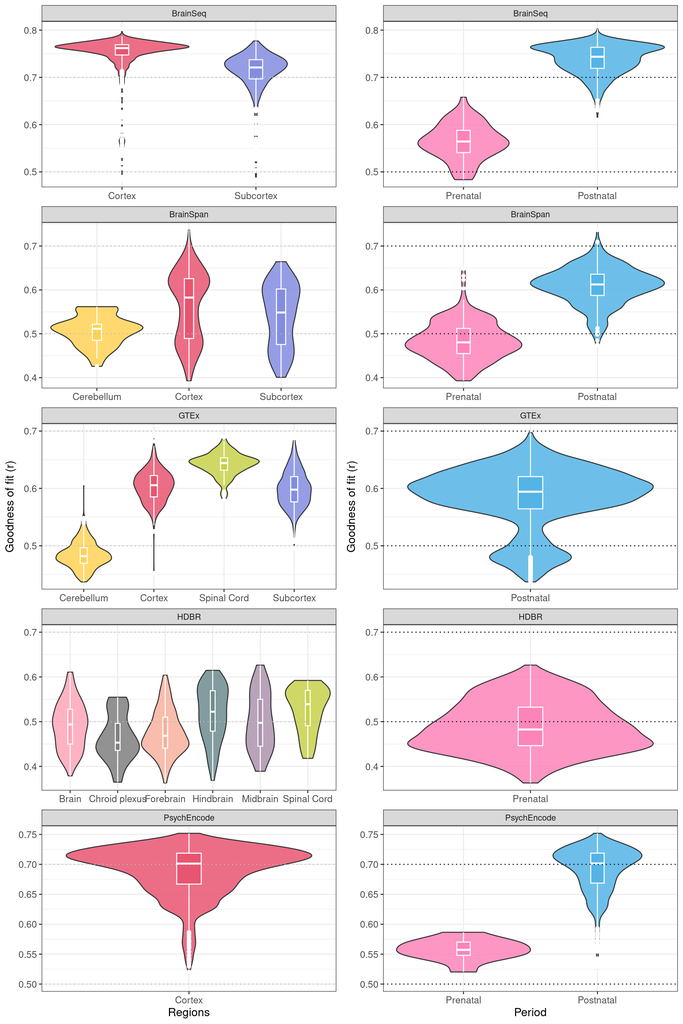

Violin plots of goodness-of-fit across all bulk RNA-seq datasets hosted on BITHub. The rows represent the RNA-seq datasets, whereas the columns, marked in different colors, represent either regions or developmental periods. The top, middle and bottom of the white internal boxes mark the 75th, 50th and 25th percentiles, respectively, whereas the width of the colored violin represents the distribution of the points.

```r
cbs_regions = do.call(rbind, gof_results) %>%
  as.data.frame() %>%
  drop_na(Regions) %>%
    ggplot(aes(Regions, r, fill = Regions)) + geom_violin(width=1, alpha = 0.85) +
      geom_boxplot(width=0.1, color="white") +
      theme_bw() +   scale_fill_manual(values = c("Cortex" = "#E85571",
                                 "Subcortex" = "#838DE0",
                                 "Cerebellum" = "#FFD256",
                                 "Spinal Cord" = "#C6D14A",
                                 "Forebrain" = "#F6B19D", #
                                 "Midbrain" = "#AC93AD",
                                 "Hindbrain" = "#6E8B8E",
                                 "Brain" = "#FFA6B7",
                                 "Forebrain and midbrain" = "#9D696C"
                                )) +
  geom_hline(yintercept = c(0.5,0.7), color = "grey",linetype='dotted') +
  ylab("Goodness of fit (r)") + facet_wrap(~Dataset, scales = "free",  nrow = 6) +
  theme(legend.position = "none",
        axis.text = element_text(size =10),
        axis.title  = element_text(size =12))

cbs_period =do.call(rbind, gof_results) %>%
  as.data.frame() %>%
  drop_na(Regions) %>%
  mutate(Period = factor(Period, levels=c("Prenatal", "Postnatal"))) %>%
    ggplot(aes(Period, r, fill = Period)) + geom_violin(width=1, alpha = 0.85) +
      geom_boxplot(width=0.1, color="white") +
      theme_bw() +  scale_fill_manual(values = c("Prenatal" = "#FD84B8",
                                                "Postnatal" = "#54B4E6")) +
  geom_hline(yintercept = c(0.5,0.7), color = "black",linetype='dotted') +
  ylab("Goodness of fit (r)") + facet_wrap(~Dataset, scales = "free",  nrow = 6) +
  theme(legend.position = "none",
        axis.text = element_text(size =10),
        axis.title  = element_text(size =12))




grid.arrange(cbs_regions, cbs_period, ncol=2)
```

```r
do.call(rbind, gof_results) %>%
  as.data.frame() %>%
  group_by(Dataset, Regions) %>%
  drop_na(Regions) %>%
    summarise(
    median_value = median(r, na.rm = TRUE),
    .groups = "drop"
  ) %>% DT::datatable(caption= c("Table showing the median goodness-of-fit (r) for each dataset across each region."))
```

|  | Dataset | Regions | median_value |
| --- | --- | --- | --- |
| 1 | BrainSeq | Cortex | 0.7619552227186105 |
| 2 | BrainSeq | Subcortex | 0.7209698443314811 |
| 3 | BrainSpan | Cerebellum | 0.5114016325106225 |
| 4 | BrainSpan | Cortex | 0.5825963242843998 |
| 5 | BrainSpan | Subcortex | 0.5484440446072234 |
| 6 | GTEx | Cerebellum | 0.4818971142577514 |
| 7 | GTEx | Cortex | 0.6055892153964257 |
| 8 | GTEx | Spinal Cord | 0.6441542352032483 |
| 9 | GTEx | Subcortex | 0.5978508728822379 |
| 10 | HDBR | Brain | 0.493760721394973 |

[output cut: 6 more lines]

```r
do.call(rbind, gof_results) %>%
  as.data.frame() %>%
  group_by(Dataset, Period) %>%
 drop_na(Period) %>%
    summarise(
    median_value = median(r, na.rm = TRUE),
    .groups = "drop"
  ) %>% DT::datatable(caption = c("Table showing the median goodness-of-fit (r) for each dataset across each developmental period."))
```

|  | Dataset | Period | median_value |
| --- | --- | --- | --- |
| 1 | BrainSeq | Postnatal | 0.7436769134760397 |
| 2 | BrainSeq | Prenatal | 0.564272827795975 |
| 3 | BrainSpan | Postnatal | 0.612432887535413 |
| 4 | BrainSpan | Prenatal | 0.4803892699635411 |
| 5 | GTEx | Postnatal | 0.5942904538686693 |
| 6 | HDBR | Prenatal | 0.4825262709178998 |
| 7 | PsychEncode | Postnatal | 0.7015291208420736 |
| 8 | PsychEncode | Prenatal | 0.5571578482664687 |

```r
do.call(rbind, gof_results) %>%
  as.data.frame() %>%
  group_by(Dataset, Period, Regions) %>%
 drop_na(Period) %>%
    summarise(
    median_value = median(r, na.rm = TRUE),
    .groups = "drop"
  ) %>% DT::datatable(caption = c("Table showing the median goodness-of-fit (r) for each dataset across each region and developmental period."))
```

|  | Dataset | Period | Regions | median_value |
| --- | --- | --- | --- | --- |
| 1 | BrainSeq | Postnatal | Cortex | 0.7626580938463098 |
| 2 | BrainSeq | Postnatal | Subcortex | 0.7229652572301312 |
| 3 | BrainSeq | Prenatal | Cortex | 0.5636924549338113 |
| 4 | BrainSeq | Prenatal | Subcortex | 0.5661349658854289 |
| 5 | BrainSpan | Postnatal | Cerebellum | 0.5207438185488461 |
| 6 | BrainSpan | Postnatal | Cortex | 0.6196635829814052 |
| 7 | BrainSpan | Postnatal | Subcortex | 0.5992787357155347 |
| 8 | BrainSpan | Prenatal | Cerebellum | 0.4789721092985283 |
| 9 | BrainSpan | Prenatal | Cortex | 0.4814434239802396 |
| 10 | BrainSpan | Prenatal | Subcortex | 0.4703259915059156 |

[output cut: 12 more lines]

## Trends

The cell type fractions were then used to determine the cell type proportion trends for each dataset across each region.

### BrainSeq

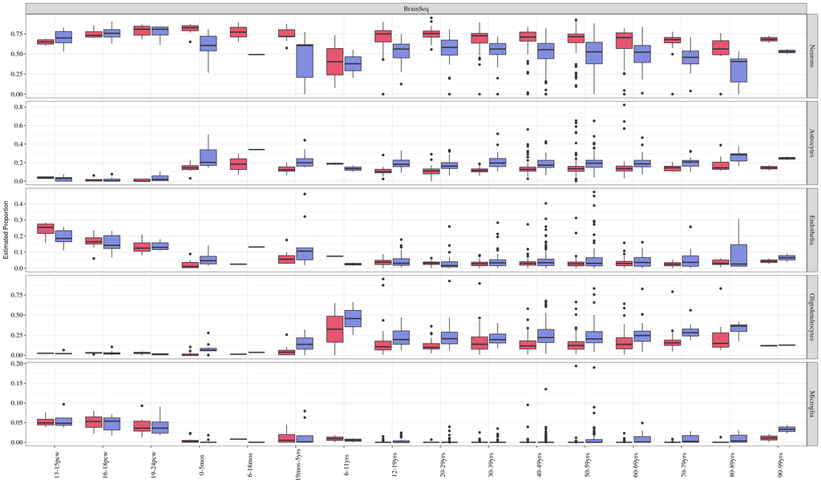

Cell-type fractions in BrainSeq dataset in each region reveal cell-type specific developmental trends. Each row represents a different cell-type fraction that was estimated using CIBERSORT and MultiBrain. The boxplots for the cell-type fractions are plotted per age interval and colored by brain region

```r
# pdf(file = here::here("output/Thesis_plots/Deconvolution/cbs-estimates-GTEx.pdf"), height =12,

decon_results$brainseq %>%
  as.data.frame %>%
  rownames_to_column("SampleID") %>%
  dplyr::select(-c("P-value", "Correlation", "RMSE")) %>%
  reshape2::melt() %>%
  left_join(read.csv(here::here("output/metadata/BrainSeq-metadata.csv"), check.names = FALSE) %>%
              dplyr::select(SampleID, Regions, `Age Interval`), by = "SampleID") %>%
  drop_na(Regions) %>%
  mutate(variable= factor(variable, levels = c("Neurons","Astrocytes",
                                               "Endothelia", "Oligodendrocytes",
                                               "Microglia"

                                              )),
        Regions = factor(Regions,
                         levels = c("Brain", "Forebrain","Hindbrain",
                                    "Midbrain", "Chroid plexus",
                                    "Cortex", "Subcortex",
                                    "Cerebellum", "Spinal Cord")),
        `Age Interval` = factor(`Age Interval`, levels = c("4-7pcw", "8-9pcw",
                                                        "10-12pcw", "13-15pcw", "16-18pcw",
                                                        "19-24pcw", "25-38pcw", "0-5mos",
                                                        "6-18mos", "19mos-5yrs", "6-11yrs",
                                                        "12-19yrs", "20-29yrs", "30-39yrs",
                                                      "40-49yrs", "50-59yrs", "60-69yrs",
                                                      "70-79yrs", "80-89yrs", "90-99yrs"))) %>%
  mutate(Dataset = c("BrainSeq")) %>%
  ggplot(aes(x = `Age Interval`, y = value, fill = Regions)) + geom_boxplot() +
  theme_bw() +
   theme(axis.text.x = element_text(size = 12, family = "serif", color = "black", angle = 90),
        axis.text.y = element_text(size = 12, family = "serif", color = "black"),
        legend.position = "none",
        strip.text = element_text(size = 12,family = "serif")) +
  facet_grid(variable~Dataset, scales = "free") +ylab("Estimated Proportion") + xlab("") +
  scale_fill_manual(values = c("Cortex" = "#E85571",
                                 "Subcortex" = "#838DE0",
                                 "Cerebellum" = "#FFD256",
                                 "Spinal Cord" = "#C6D14A",
                                 "Forebrain" = "#F6B19D", #
                                 "Midbrain" = "#AC93AD",
                                 "Hindbrain" = "#6E8B8E",
                                 "Brain" = "#FFA6B7",
                                 "Chroid plexus" = "#9D696C"
                                ))
```

```r
#dev.off()
```

```r
decon_results$brainseq %>%
  as.data.frame %>%
  rownames_to_column("SampleID") %>%
  dplyr::select(-c("P-value", "Correlation", "RMSE")) %>%
  reshape2::melt() %>%
    left_join(read.csv(here::here("output/metadata/BrainSeq-metadata.csv"), check.names = FALSE) %>%
              dplyr::select(SampleID, Regions, `Age Interval`), by = "SampleID") %>%
  drop_na(Regions) %>%
  group_by(Regions, variable) %>%
    summarise(value = sum(value, na.rm = TRUE), .groups = "drop_last") %>%
    mutate(percent = value / sum(value) * 100) %>%
    ungroup() %>% DT::datatable(caption = c("Percentage of cell types for each region within the BrainSeq dataset"))
```

|  | Regions | variable | value | percent |
| --- | --- | --- | --- | --- |
| 1 | Cortex | Neurons | 308.9606965231485 | 68.20324426559569 |
| 2 | Cortex | Astrocytes | 60.54679789053045 | 13.36573904868222 |
| 3 | Cortex | Oligodendrocytes | 62.98610242847651 | 13.90421687162837 |
| 4 | Cortex | Microglia | 2.080536711577809 | 0.4592796272798695 |
| 5 | Cortex | Endothelia | 18.42586644626676 | 4.067520186813853 |
| 6 | Subcortex | Neurons | 233.5087662750073 | 52.23909760067278 |
| 7 | Subcortex | Astrocytes | 83.00423258485789 | 18.56917954918521 |
| 8 | Subcortex | Oligodendrocytes | 99.67682593237349 | 22.2990662041104 |
| 9 | Subcortex | Microglia | 3.784748021397478 | 0.8466997810732612 |
| 10 | Subcortex | Endothelia | 27.02542718636386 | 6.045956864958358 |

### BrainSpan

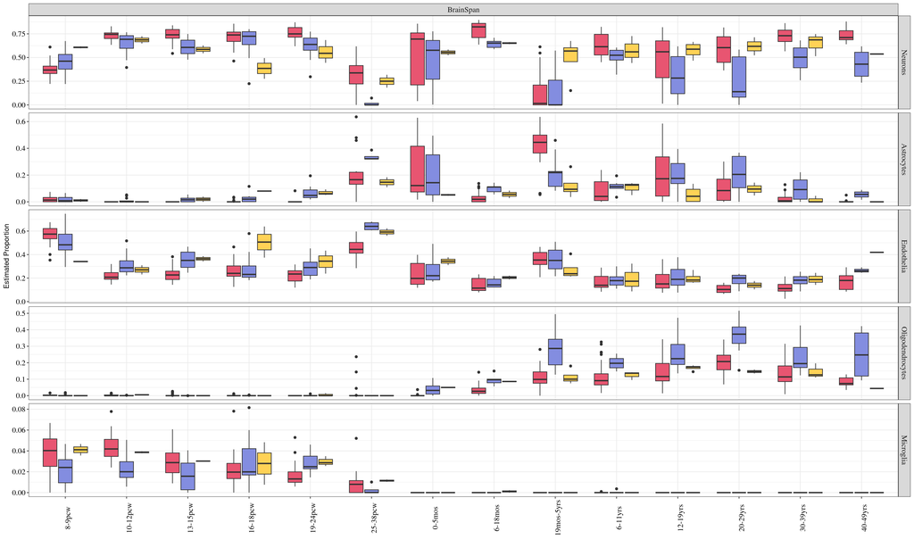

Cell-type fractions in BrainSpan dataset in each region reveal cell-type specific developmental trends. Each row represents a different cell-type fraction that was estimated using CIBERSORT and MultiBrain. The boxplots for the cell-type fractions are plotted per age interval and colored by brain region.

```r
# pdf(file = here::here("output/Thesis_plots/Deconvolution/cbs-estimates-GTEx.pdf"), height =12,

decon_results$brainspan %>%
  as.data.frame %>%
  rownames_to_column("SampleID") %>%
 # mutate(SampleID = gsub("^X","", SampleID)) %>%
  dplyr::select(-c("P-value", "Correlation", "RMSE")) %>%
  reshape2::melt() %>%
  left_join(read.csv(here::here("output/metadata/BrainSpan-metadata.csv"), check.names = FALSE) %>%
              dplyr::select(SampleID, Regions, `Age Interval`), by = "SampleID") %>%
  drop_na(Regions) %>%
  mutate(variable= factor(variable, levels = c("Neurons","Astrocytes",
                                               "Endothelia", "Oligodendrocytes",
                                               "Microglia"

                                              )),
        Regions = factor(Regions,
                         levels = c("Brain", "Forebrain","Hindbrain",
                                    "Midbrain", "Chroid plexus",
                                    "Cortex", "Subcortex",
                                    "Cerebellum", "Spinal Cord")),
        `Age Interval` = factor(`Age Interval`, levels = c("4-7pcw", "8-9pcw",
                                                        "10-12pcw", "13-15pcw", "16-18pcw",
                                                        "19-24pcw", "25-38pcw", "0-5mos",
                                                        "6-18mos", "19mos-5yrs", "6-11yrs",
                                                        "12-19yrs", "20-29yrs", "30-39yrs",
                                                      "40-49yrs", "50-59yrs", "60-69yrs",
                                                      "70-79yrs", "80-89yrs", "90-99yrs"))) %>%
  mutate(Dataset = c("BrainSpan")) %>%
  ggplot(aes(x = `Age Interval`, y = value, fill = Regions)) + geom_boxplot() +
  theme_bw() +
   theme(axis.text.x = element_text(size = 12, family = "serif", color = "black", angle = 90),
        axis.text.y = element_text(size = 12, family = "serif", color = "black"),
        legend.position = "none",
        strip.text = element_text(size = 12,family = "serif")) +
  facet_grid(variable~Dataset, scales = "free") +ylab("Estimated Proportion") + xlab("") +
  scale_fill_manual(values = c("Cortex" = "#E85571",
                                 "Subcortex" = "#838DE0",
                                 "Cerebellum" = "#FFD256",
                                 "Spinal Cord" = "#C6D14A",
                                 "Forebrain" = "#F6B19D", #
                                 "Midbrain" = "#AC93AD",
                                 "Hindbrain" = "#6E8B8E",
                                 "Brain" = "#FFA6B7",
                                 "Chroid plexus" = "#9D696C"
                                ))
```

```r
#dev.off()
```

```r
decon_results$brainspan%>%
  as.data.frame %>%
  rownames_to_column("SampleID") %>%
  dplyr::select(-c("P-value", "Correlation", "RMSE")) %>%
  reshape2::melt() %>%
    left_join(read.csv(here::here("output/metadata/BrainSpan-metadata.csv"), check.names = FALSE) %>%
              dplyr::select(SampleID, Regions, `Age Interval`), by = "SampleID") %>%
  drop_na(Regions) %>%
  group_by(Regions, variable) %>%
    summarise(value = sum(value, na.rm = TRUE), .groups = "drop_last") %>%
    mutate(percent = value / sum(value) * 100) %>%
    ungroup() %>% DT::datatable(caption =  c("Percentage of cell types for each region within the BrainSpan dataset"))
```

|  | Regions | variable | value | percent |
| --- | --- | --- | --- | --- |
| 1 | Cerebellum | Neurons | 18.83580916906234 | 55.3994387325363 |
| 2 | Cerebellum | Astrocytes | 2.192845254266815 | 6.449544865490632 |
| 3 | Cerebellum | Oligodendrocytes | 2.573940379709973 | 7.570412881499921 |
| 4 | Cerebellum | Microglia | 0.3901509365764675 | 1.147502754636669 |
| 5 | Cerebellum | Endothelia | 10.0072542603844 | 29.43310076583647 |
| 6 | Cortex | Neurons | 216.7974787572925 | 59.88880628654491 |
| 7 | Cortex | Astrocytes | 34.32055121001967 | 9.48081525138665 |
| 8 | Cortex | Oligodendrocytes | 22.6366453038711 | 6.253216934771022 |
| 9 | Cortex | Microglia | 4.381724111270748 | 1.210421025212914 |
| 10 | Cortex | Endothelia | 83.86360061754597 | 23.16674050208452 |

[output cut: 5 more lines]

### GTEx

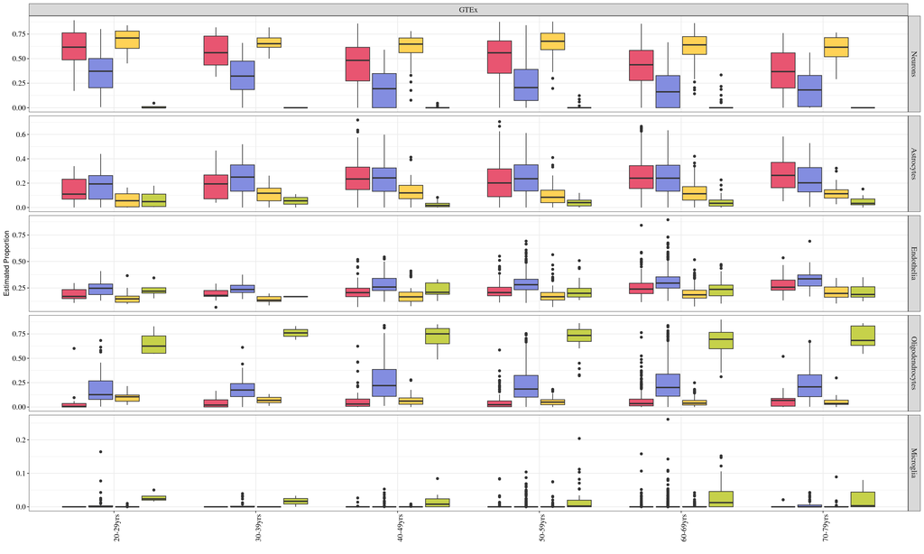

Cell-type fractions in GTEx dataset in each region reveal cell-type specific developmental trends. Each row represents a different cell-type fraction that was estimated using CIBERSORT and MultiBrain. The boxplots for the cell-type fractions are plotted per age interval and colored by brain region

```r
# pdf(file = here::here("output/Thesis_plots/Deconvolution/cbs-estimates-GTEx.pdf"), height =12,

decon_results$gtex %>%
  as.data.frame %>%
  rownames_to_column("SampleID") %>%
 # mutate(SampleID = gsub("^X","", SampleID)) %>%
  dplyr::select(-c("P-value", "Correlation", "RMSE")) %>%
  reshape2::melt() %>%
  left_join(read.csv(here::here("output/metadata/GTEx-metadata.csv"), check.names = FALSE) %>%
              dplyr::select(SampleID, Regions, `Age Interval`), by = "SampleID") %>%
  drop_na(Regions) %>%
  mutate(variable= factor(variable, levels = c("Neurons","Astrocytes",
                                               "Endothelia", "Oligodendrocytes",
                                               "Microglia"

                                              )),
        Regions = factor(Regions,
                         levels = c("Brain", "Forebrain","Hindbrain",
                                    "Midbrain", "Chroid plexus",
                                    "Cortex", "Subcortex",
                                    "Cerebellum", "Spinal Cord")),
        `Age Interval` = factor(`Age Interval`, levels = c("4-7pcw", "8-9pcw",
                                                        "10-12pcw", "13-15pcw", "16-18pcw",
                                                        "19-24pcw", "25-38pcw", "0-5mos",
                                                        "6-18mos", "19mos-5yrs", "6-11yrs",
                                                        "12-19yrs", "20-29yrs", "30-39yrs",
                                                      "40-49yrs", "50-59yrs", "60-69yrs",
                                                      "70-79yrs", "80-89yrs", "90-99yrs"))) %>%
  mutate(Dataset = c("GTEx")) %>%
  ggplot(aes(x = `Age Interval`, y = value, fill = Regions)) + geom_boxplot() +
  theme_bw() +
   theme(axis.text.x = element_text(size = 12, family = "serif", color = "black", angle = 90),
        axis.text.y = element_text(size = 12, family = "serif", color = "black"),
        legend.position = "none",
        strip.text = element_text(size = 12,family = "serif")) +
  facet_grid(variable~Dataset, scales = "free") +ylab("Estimated Proportion") + xlab("") +
  scale_fill_manual(values = c("Cortex" = "#E85571",
                                 "Subcortex" = "#838DE0",
                                 "Cerebellum" = "#FFD256",
                                 "Spinal Cord" = "#C6D14A",
                                 "Forebrain" = "#F6B19D", #
                                 "Midbrain" = "#AC93AD",
                                 "Hindbrain" = "#6E8B8E",
                                 "Brain" = "#FFA6B7",
                                 "Chroid plexus" = "#9D696C"
                                ))
```

```r
#dev.off()
```

```r
decon_results$gtex %>%
  as.data.frame %>%
  rownames_to_column("SampleID") %>%
  dplyr::select(-c("P-value", "Correlation", "RMSE")) %>%
  reshape2::melt() %>%
    left_join(read.csv(here::here("output/metadata/GTEx-metadata.csv"), check.names = FALSE) %>%
              dplyr::select(SampleID, Regions, `Age Interval`), by = "SampleID") %>%
  drop_na(Regions) %>%
  group_by(variable) %>%
    summarise(value = sum(value, na.rm = TRUE), .groups = "drop_last") %>%
    mutate(percent = value / sum(value) * 100) %>%
    ungroup() %>% DT::datatable(caption =  c("Percentage of cell types  within the GTEx dataset"))
```

|  | variable | value | percent |
| --- | --- | --- | --- |
| 1 | Neurons | 874.4684889126672 | 33.09873160153926 |
| 2 | Astrocytes | 549.538066812822 | 20.8000782291 |
| 3 | Oligodendrocytes | 509.3104709341067 | 19.27745915723341 |
| 4 | Microglia | 12.09078852961873 | 0.457637718759225 |
| 5 | Endothelia | 696.5921848107854 | 26.36609329336811 |

```r
decon_results$gtex %>%
  as.data.frame %>%
  rownames_to_column("SampleID") %>%
  dplyr::select(-c("P-value", "Correlation", "RMSE")) %>%
  reshape2::melt() %>%
    left_join(read.csv(here::here("output/metadata/GTEx-metadata.csv"), check.names = FALSE) %>%
              dplyr::select(SampleID, Regions, `Age Interval`), by = "SampleID") %>%
  drop_na(Regions) %>%
  group_by(Regions, variable) %>%
    summarise(value = sum(value, na.rm = TRUE), .groups = "drop_last") %>%
    mutate(percent = value / sum(value) * 100) %>%
    ungroup() %>% DT::datatable(caption =  c("Percentage of cell types for each region within the GTEx dataset"))
```

|  | Regions | variable | value | percent |
| --- | --- | --- | --- | --- |
| 1 | Cerebellum | Neurons | 289.3614250682895 | 63.45645286585295 |
| 2 | Cerebellum | Astrocytes | 51.4076867264735 | 11.27361551019156 |
| 3 | Cerebellum | Oligodendrocytes | 25.88706244953474 | 5.676987379283934 |
| 4 | Cerebellum | Microglia | 1.01251228848446 | 0.2220421685272937 |
| 5 | Cerebellum | Endothelia | 88.33131346721781 | 19.37090207614425 |
| 6 | Cortex | Neurons | 290.1255715854483 | 45.33212056022629 |
| 7 | Cortex | Astrocytes | 152.9753589736671 | 23.90239983963548 |
| 8 | Cortex | Oligodendrocytes | 41.24344566962925 | 6.44428838587957 |
| 9 | Cortex | Microglia | 1.011017654737903 | 0.1579715085527973 |
| 10 | Cortex | Endothelia | 154.6446061165174 | 24.16321970570585 |

[output cut: 10 more lines]

### HDBR

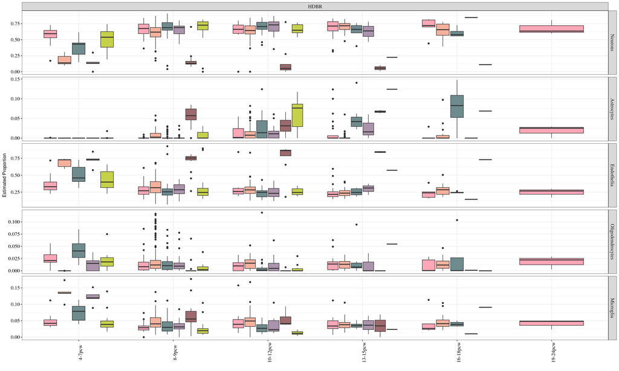

Cell-type fractions in HDBR dataset in each region reveal cell-type specific developmental trends. Each row represents a different cell-type fraction that was estimated using CIBERSORT and MultiBrain. The boxplots for the cell-type fractions are plotted per age interval and colored by brain region

```r
# pdf(file = here::here("output/Thesis_plots/Deconvolution/cbs-estimates-GTEx.pdf"), height =12,

decon_results$hdbr %>%
  as.data.frame %>%
  rownames_to_column("SampleID") %>%
  dplyr::select(-c("P-value", "Correlation", "RMSE")) %>%
  reshape2::melt() %>%
  left_join(read.csv(here::here("output/metadata/HDBR-metadata.csv"), check.names = FALSE) %>%
              dplyr::select(SampleID, Regions, `Age Interval`), by = "SampleID") %>%
  drop_na(Regions) %>%
  mutate(variable= factor(variable, levels = c("Neurons","Astrocytes",
                                               "Endothelia", "Oligodendrocytes",
                                               "Microglia"

                                              )),
        Regions = factor(Regions,
                         levels = c("Brain", "Forebrain","Hindbrain",
                                    "Midbrain", "Chroid plexus",
                                    "Cortex", "Subcortex",
                                    "Cerebellum", "Spinal Cord")),
        `Age Interval` = factor(`Age Interval`, levels = c("4-7pcw", "8-9pcw",
                                                        "10-12pcw", "13-15pcw", "16-18pcw",
                                                        "19-24pcw", "25-38pcw", "0-5mos",
                                                        "6-18mos", "19mos-5yrs", "6-11yrs",
                                                        "12-19yrs", "20-29yrs", "30-39yrs",
                                                      "40-49yrs", "50-59yrs", "60-69yrs",
                                                      "70-79yrs", "80-89yrs", "90-99yrs"))) %>%
  mutate(Dataset = c("HDBR")) %>%
  ggplot(aes(x = `Age Interval`, y = value, fill = Regions)) + geom_boxplot() +
  theme_bw() +
   theme(axis.text.x = element_text(size = 12, family = "serif", color = "black", angle = 90),
        axis.text.y = element_text(size = 12, family = "serif", color = "black"),
        legend.position = "none",
        strip.text = element_text(size = 12,family = "serif")) +
  facet_grid(variable~Dataset, scales = "free") +ylab("Estimated Proportion") + xlab("") +
  scale_fill_manual(values = c("Cortex" = "#E85571",
                                 "Subcortex" = "#838DE0",
                                 "Cerebellum" = "#FFD256",
                                 "Spinal Cord" = "#C6D14A",
                                 "Forebrain" = "#F6B19D", #
                                 "Midbrain" = "#AC93AD",
                                 "Hindbrain" = "#6E8B8E",
                                 "Brain" = "#FFA6B7",
                                 "Chroid plexus" = "#9D696C"
                                ))
```

```r
#dev.off()
```

```r
decon_results$hdbr %>%
  as.data.frame %>%
  rownames_to_column("SampleID") %>%
  dplyr::select(-c("P-value", "Correlation", "RMSE")) %>%
  reshape2::melt() %>%
    left_join(read.csv(here::here("output/metadata/HDBR-metadata.csv"), check.names = FALSE) %>%
              dplyr::select(SampleID, Regions, `Age Interval`), by = "SampleID") %>%
  drop_na(Regions) %>%
  group_by(Regions, variable) %>%
    summarise(value = sum(value, na.rm = TRUE), .groups = "drop_last") %>%
    mutate(percent = value / sum(value) * 100) %>%
    ungroup() %>% DT::datatable(caption =  c("Percentage of cell types for each region within the HDBR dataset"))
```

|  | Regions | variable | value | percent |
| --- | --- | --- | --- | --- |
| 1 | Brain | Neurons | 65.4892085803436 | 64.20510645131725 |
| 2 | Brain | Astrocytes | 0.6283520733781718 | 0.6160314444884036 |
| 3 | Brain | Oligodendrocytes | 1.689461871019435 | 1.656335167666112 |
| 4 | Brain | Microglia | 3.987101293182943 | 3.908922836453866 |
| 5 | Brain | Endothelia | 30.20587618207585 | 29.61360410007436 |
| 6 | Chroid plexus | Neurons | 4.50403006304532 | 15.53113814843214 |
| 7 | Chroid plexus | Astrocytes | 1.452383701435584 | 5.008219660122704 |
| 8 | Chroid plexus | Oligodendrocytes | 0.09897400441794281 | 0.3412896704066993 |
| 9 | Chroid plexus | Microglia | 1.790088158700519 | 6.172717788622478 |
| 10 | Chroid plexus | Endothelia | 21.15452407240063 | 72.94663473241599 |

[output cut: 20 more lines]

### PsychEncode

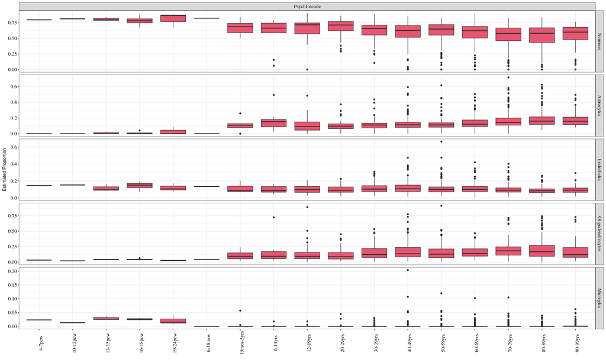

Cell-type fractions in PsychEncode dataset in each region reveal cell-type specific developmental trends. Each row represents a different cell-type fraction that was estimated using CIBERSORT and MultiBrain. The boxplots for the cell-type fractions are plotted per age interval and colored by brain region

```r
# pdf(file = here::here("output/Thesis_plots/Deconvolution/cbs-estimates-GTEx.pdf"), height =12,

decon_results$psychencode %>%
  as.data.frame %>%
  rownames_to_column("SampleID") %>%
  dplyr::select(-c("P-value", "Correlation", "RMSE")) %>%
  reshape2::melt() %>%
  left_join(read.csv(here::here("output/metadata/PsychEncode-metadata.csv"), check.names = FALSE) %>%
              dplyr::select(SampleID, Regions, `Age Interval`), by = "SampleID") %>%
  drop_na(Regions) %>%
  mutate(variable= factor(variable, levels = c("Neurons","Astrocytes",
                                               "Endothelia", "Oligodendrocytes",
                                               "Microglia"

                                              )),
        Regions = factor(Regions,
                         levels = c("Brain", "Forebrain","Hindbrain",
                                    "Midbrain", "Chroid plexus",
                                    "Cortex", "Subcortex",
                                    "Cerebellum", "Spinal Cord")),
        `Age Interval` = factor(`Age Interval`, levels = c("4-7pcw", "8-9pcw",
                                                        "10-12pcw", "13-15pcw", "16-18pcw",
                                                        "19-24pcw", "25-38pcw", "0-5mos",
                                                        "6-18mos", "19mos-5yrs", "6-11yrs",
                                                        "12-19yrs", "20-29yrs", "30-39yrs",
                                                      "40-49yrs", "50-59yrs", "60-69yrs",
                                                      "70-79yrs", "80-89yrs", "90-99yrs"))) %>%
  mutate(Dataset = c("PsychEncode")) %>%
  ggplot(aes(x = `Age Interval`, y = value, fill = Regions)) + geom_boxplot() +
  theme_bw() +
   theme(axis.text.x = element_text(size = 12, family = "serif", color = "black", angle = 90),
        axis.text.y = element_text(size = 12, family = "serif", color = "black"),
        legend.position = "none",
        strip.text = element_text(size = 12,family = "serif")) +
  facet_grid(variable~Dataset, scales = "free") +ylab("Estimated Proportion") + xlab("") +
  scale_fill_manual(values = c("Cortex" = "#E85571",
                                 "Subcortex" = "#838DE0",
                                 "Cerebellum" = "#FFD256",
                                 "Spinal Cord" = "#C6D14A",
                                 "Forebrain" = "#F6B19D", #
                                 "Midbrain" = "#AC93AD",
                                 "Hindbrain" = "#6E8B8E",
                                 "Brain" = "#FFA6B7",
                                 "Chroid plexus" = "#9D696C"
                                ))
```

```r
#dev.off()
```

```r
decon_results$psychencode %>%
  as.data.frame %>%
  rownames_to_column("SampleID") %>%
  dplyr::select(-c("P-value", "Correlation", "RMSE")) %>%
  reshape2::melt() %>%
    left_join(read.csv(here::here("output/metadata/PsychEncode-metadata.csv"), check.names = FALSE) %>%
              dplyr::select(SampleID, Regions, `Age Interval`), by = "SampleID") %>%
  drop_na(Regions) %>%
  group_by(Regions, variable) %>%
    summarise(value = sum(value, na.rm = TRUE), .groups = "drop_last") %>%
    mutate(percent = value / sum(value) * 100) %>%
    ungroup() %>% DT::datatable(caption =  c("Percentage of cell types for each region within the PsychEncode dataset"))
```

|  | Regions | variable | value | percent |
| --- | --- | --- | --- | --- |
| 1 | Cortex | Neurons | 798.8274438483827 | 58.2660425855859 |
| 2 | Cortex | Astrocytes | 189.7105399162073 | 13.83738438484371 |
| 3 | Cortex | Oligodendrocytes | 231.6225862111404 | 16.89442641948508 |
| 4 | Cortex | Microglia | 3.461072719112658 | 0.2524487760111348 |
| 5 | Cortex | Endothelia | 147.3783573051569 | 10.74969783407417 |

## Export the data

```r
decon_results$brainseq %<>%
  as.data.frame() %>%
    rownames_to_column("SampleID") %>%
    dplyr::select(SampleID,
                "Proportion of Neurons (MultiBrain)" = "Neurons",
                "Proportion of Astrocytes (MultiBrain)" = "Astrocytes",
                "Proportion of Microglia (MultiBrain)" = "Microglia",
                "Proportion of Oligodendrocytes (MultiBrain)" = "Oligodendrocytes",
                "Proportion of Endothelia (MultiBrain)" = "Endothelia")


order.bseq = read.csv(here::here("data/annotations/BrainSeq-annot-final.csv"),check.names = FALSE)


bseq.full.md= read.csv(here::here("output/metadata/BrainSeq-metadata.csv"), check.names = FALSE) %>%
  left_join(decon_results$brainseq, by = "SampleID") %>%
  dplyr::select(contains(order.bseq$BITColumnName))



write.csv(bseq.full.md, here::here("output/metadata/BrainSeq-metadata.csv"))
write.csv(decon_results$brainseq, here::here("output/metadata/BrainSeq-decon.csv"))
```

```r
decon_results$brainspan %<>%
  as.data.frame() %>%
    rownames_to_column("SampleID") %>%
    dplyr::select(SampleID,
                "Proportion of Neurons (MultiBrain)" = "Neurons",
                "Proportion of Astrocytes (MultiBrain)" = "Astrocytes",
                "Proportion of Microglia (MultiBrain)" = "Microglia",
                "Proportion of Oligodendrocytes (MultiBrain)" = "Oligodendrocytes",
                "Proportion of Endothelia (MultiBrain)" = "Endothelia")


order.bspan = read.csv(here::here("data/annotations/BrainSpan-annot-final.csv"),check.names = FALSE)


bspan.full.md= read.csv(here::here("output/metadata/BrainSpan-metadata.csv"), check.names = FALSE) %>%
  left_join(decon_results$brainspan, by = "SampleID") %>%
  dplyr::select(SampleID, contains(order.bspan$BITColumnName))




write.csv(bspan.full.md, here::here("output/metadata/BrainSpan-metadata.csv"))
write.csv(decon_results$brainspan, here::here("output/metadata/BrainSpan-decon.csv"))
```

```r
decon_results$gtex %<>%
  as.data.frame() %>%
    rownames_to_column("SampleID") %>%
    dplyr::select(SampleID,
                "Proportion of Neurons (MultiBrain)" = "Neurons",
                "Proportion of Astrocytes (MultiBrain)" = "Astrocytes",
                "Proportion of Microglia (MultiBrain)" = "Microglia",
                "Proportion of Oligodendrocytes (MultiBrain)" = "Oligodendrocytes",
                "Proportion of Endothelia (MultiBrain)" = "Endothelia")


order.gtex = read.csv(here::here("data/annotations/GTEx-annot-final.csv"),check.names = FALSE)


gtex.full.md= read.csv(here::here("output/metadata/GTEx-metadata.csv"), check.names = FALSE) %>%
  left_join(decon_results$gtex, by = "SampleID") %>%
  dplyr::select(SampleID, contains(order.gtex$BITColumnName))




write.csv(gtex.full.md, here::here("output/metadata/GTEx-metadata.csv"))
write.csv(decon_results$gtex, here::here("output/metadata/GTEx-decon.csv"))
```

```r
decon_results$hdbr %<>%
  as.data.frame() %>%
    rownames_to_column("SampleID") %>%
    dplyr::select(SampleID,
                "Proportion of Neurons (MultiBrain)" = "Neurons",
                "Proportion of Astrocytes (MultiBrain)" = "Astrocytes",
                "Proportion of Microglia (MultiBrain)" = "Microglia",
                "Proportion of Oligodendrocytes (MultiBrain)" = "Oligodendrocytes",
                "Proportion of Endothelia (MultiBrain)" = "Endothelia")


order.hdbr = read.csv(here::here("data/annotations/HDBR-annot-final.csv"),check.names = FALSE)


hdbr.full.md= read.csv(here::here("output/metadata/HDBR-metadata.csv"), check.names = FALSE) %>%
  left_join(decon_results$hdbr, by = "SampleID") %>%
  dplyr::select(SampleID, contains(order.hdbr$BITColumnName))




write.csv(hdbr.full.md, here::here("output/metadata/HDBR-metadata.csv"))
write.csv(decon_results$hdbr, here::here("output/metadata/HDBR-decon.csv"))
```

```r
decon_results$psychencode %<>%
  as.data.frame() %>%
    rownames_to_column("SampleID") %>%
    dplyr::select(SampleID,
                "Proportion of Neurons (MultiBrain)" = "Neurons",
                "Proportion of Astrocytes (MultiBrain)" = "Astrocytes",
                "Proportion of Microglia (MultiBrain)" = "Microglia",
                "Proportion of Oligodendrocytes (MultiBrain)" = "Oligodendrocytes",
                "Proportion of Endothelia (MultiBrain)" = "Endothelia")


order.pe = read.csv(here::here("data/annotations/PE-annot-final.csv"),check.names = FALSE)


pe.full.md= read.csv(here::here("output/metadata/PsychEncode-metadata.csv"), check.names = FALSE) %>%
  left_join(decon_results$psychencode, by = "SampleID") %>%
  dplyr::select(contains(order.pe$BITColumnName))



write.csv(pe.full.md, here::here("output/metadata/PsychEncode-metadata.csv"))
write.csv(decon_results$psychencode, here::here("output/metadata/PsychEncode-decon.csv"))
```